# HW3

Alina

9/28/2020

```r
library('faraway')
data(pima)
summary(pima)
```

```
##     pregnant         glucose        diastolic         triceps
##  Min.   : 0.000   Min.   :  0.0   Min.   :  0.00   Min.   : 0.00
##  1st Qu.: 1.000   1st Qu.: 99.0   1st Qu.: 62.00   1st Qu.: 0.00
##  Median : 3.000   Median :117.0   Median : 72.00   Median :23.00
##  Mean   : 3.845   Mean   :120.9   Mean   : 69.11   Mean   :20.54
##  3rd Qu.: 6.000   3rd Qu.:140.2   3rd Qu.: 80.00   3rd Qu.:32.00
##  Max.   :17.000   Max.   :199.0   Max.   :122.00   Max.   :99.00
##     insulin           bmi           diabetes           age
##  Min.   :  0.0   Min.   : 0.00   Min.   :0.0780   Min.   :21.00
##  1st Qu.:  0.0   1st Qu.:27.30   1st Qu.:0.2437   1st Qu.:24.00
##  Median : 30.5   Median :32.00   Median :0.3725   Median :29.00
##  Mean   : 79.8   Mean   :31.99   Mean   :0.4719   Mean   :33.24
##  3rd Qu.:127.2   3rd Qu.:36.60   3rd Qu.:0.6262   3rd Qu.:41.00
##  Max.   :846.0   Max.   :67.10   Max.   :2.4200   Max.   :81.00
##       test
##  Min.   :0.000
##  1st Qu.:0.000
##  Median :0.000
##  Mean   :0.349
##  3rd Qu.:1.000
##  Max.   :1.000
```

Part a)

```r
pima.f<-factor(pima$test,labels=c("negative","positive"))
#levels(pima$test)<-c("negative","positive")
summary(pima.f)
```

```
## negative positive
##      500      268
```

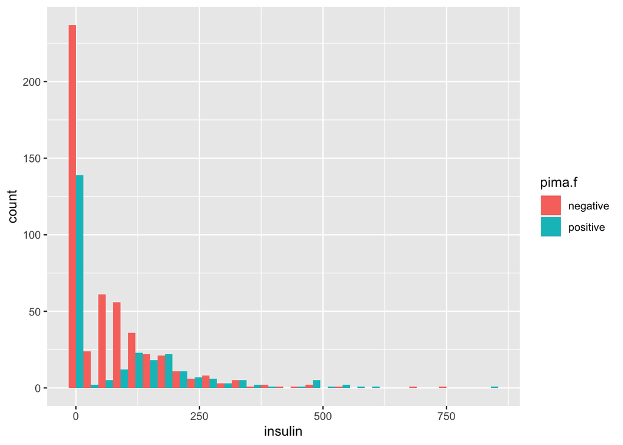

```r
library(ggplot2)
ggplot(pima,aes(x=insulin,fill=pima.f))+geom_histogram(position="dodge",binwidth=30)
```

Part b)

```r
pima$insulinNA<-pima$insulin
pima$insulinNA[pima$insulin==0]<-NA
summary(pima$insulinNA)
```

```
##    Min. 1st Qu.  Median    Mean 3rd Qu.    Max.    NA's
##   14.00   76.25  125.00  155.55  190.00  846.00     374
```

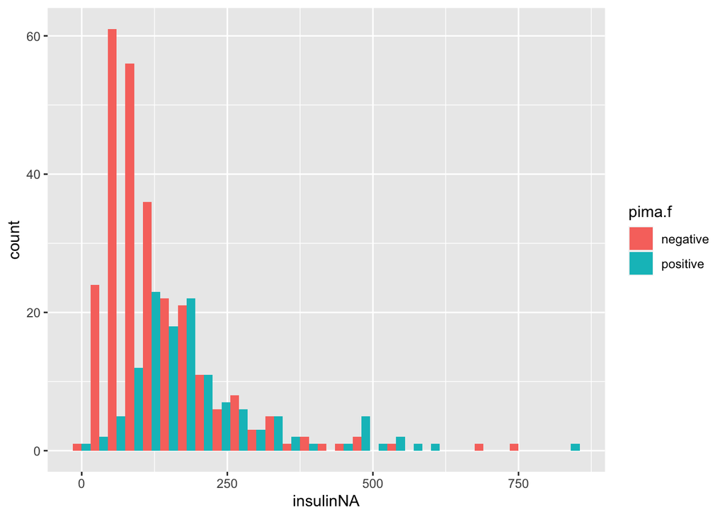

```r
library(ggplot2)
ggplot(pima,aes(x=insulinNA,fill=pima.f))+geom_histogram(position="dodge",binwidth=30)
```

The distribution close to 0 is very diverse.

Part c)

I will replace zeroes with the missing value code.

```r
pima$glucoseNA<-pima$glucose
pima$tricepsNA<-pima$triceps
pima$diastolicNA<-pima$diastolic
pima$bmiNA<-pima$bmi
pima$diastolicNA[pima$diastolic==0]<-NA
pima$glucoseNA[pima$glucose==0]<-NA
pima$tricepsNA[pima$triceps==0]<-NA
pima$bmiNA[pima$bmi==0]<-NA

summary(pima)
```

```
##     pregnant         glucose        diastolic         triceps
##  Min.   : 0.000   Min.   :  0.0   Min.   :  0.00   Min.   : 0.00
##  1st Qu.: 1.000   1st Qu.: 99.0   1st Qu.: 62.00   1st Qu.: 0.00
##  Median : 3.000   Median :117.0   Median : 72.00   Median :23.00
##  Mean   : 3.845   Mean   :120.9   Mean   : 69.11   Mean   :20.54
##  3rd Qu.: 6.000   3rd Qu.:140.2   3rd Qu.: 80.00   3rd Qu.:32.00
##  Max.   :17.000   Max.   :199.0   Max.   :122.00   Max.   :99.00
##
##     insulin           bmi           diabetes           age
##  Min.   :  0.0   Min.   : 0.00   Min.   :0.0780   Min.   :21.00
##  1st Qu.:  0.0   1st Qu.:27.30   1st Qu.:0.2437   1st Qu.:24.00
##  Median : 30.5   Median :32.00   Median :0.3725   Median :29.00
##  Mean   : 79.8   Mean   :31.99   Mean   :0.4719   Mean   :33.24
##  3rd Qu.:127.2   3rd Qu.:36.60   3rd Qu.:0.6262   3rd Qu.:41.00
##  Max.   :846.0   Max.   :67.10   Max.   :2.4200   Max.   :81.00
##
##       test         insulinNA        glucoseNA       tricepsNA
##  Min.   :0.000   Min.   : 14.00   Min.   : 44.0   Min.   : 7.00
##  1st Qu.:0.000   1st Qu.: 76.25   1st Qu.: 99.0   1st Qu.:22.00
##  Median :0.000   Median :125.00   Median :117.0   Median :29.00
##  Mean   :0.349   Mean   :155.55   Mean   :121.7   Mean   :29.15
##  3rd Qu.:1.000   3rd Qu.:190.00   3rd Qu.:141.0   3rd Qu.:36.00
##  Max.   :1.000   Max.   :846.00   Max.   :199.0   Max.   :99.00
##                  NA's   :374      NA's   :5       NA's   :227
##   diastolicNA         bmiNA
##  Min.   : 24.00   Min.   :18.20
##  1st Qu.: 64.00   1st Qu.:27.50
##  Median : 72.00   Median :32.30
##  Mean   : 72.41   Mean   :32.46
##  3rd Qu.: 80.00   3rd Qu.:36.60
##  Max.   :122.00   Max.   :67.10
##  NA's   :35       NA's   :11
```

fitting the model with test as the response

```r
lmod<-glm(test~pregnant+glucoseNA+diastolicNA+tricepsNA+insulinNA+bmiNA+diabetes+age,family=binomial,pima)
summary(lmod)
```

```
##
## Call:
## glm(formula = test ~ pregnant + glucoseNA + diastolicNA + tricepsNA +
##     insulinNA + bmiNA + diabetes + age, family = binomial, data = pima)
##
## Deviance Residuals:
##     Min       1Q   Median       3Q      Max
## -2.7823  -0.6603  -0.3642   0.6409   2.5612
##
## Coefficients:
##               Estimate Std. Error z value Pr(>|z|)
## (Intercept) -1.004e+01  1.218e+00  -8.246  < 2e-16 ***
## pregnant     8.216e-02  5.543e-02   1.482  0.13825
## glucoseNA    3.827e-02  5.768e-03   6.635 3.24e-11 ***
## diastolicNA -1.420e-03  1.183e-02  -0.120  0.90446
## tricepsNA    1.122e-02  1.708e-02   0.657  0.51128
## insulinNA   -8.253e-04  1.306e-03  -0.632  0.52757
## bmiNA        7.054e-02  2.734e-02   2.580  0.00989 **
## diabetes     1.141e+00  4.274e-01   2.669  0.00760 **
## age          3.395e-02  1.838e-02   1.847  0.06474 .
## ---
## Signif. codes:  0 '***' 0.001 '**' 0.01 '*' 0.05 '.' 0.1 ' ' 1
##
## (Dispersion parameter for binomial family taken to be 1)
##
##     Null deviance: 498.10  on 391  degrees of freedom
## Residual deviance: 344.02  on 383  degrees of freedom
##   (376 observations deleted due to missingness)
## AIC: 362.02
##
## Number of Fisher Scoring iterations: 5
```

We used 392 observations since 376 observations were deleted to avoid our model to be misleading. For some observations 0 was used as a missing value(for example, when a researcher couldn’t collect the data so he assign 0 to it), so I set all 0s as NA to make my model more accurate.

Part d)

```r
lmod2<-glm(test~pregnant+glucoseNA+diastolicNA+bmiNA+diabetes+age,family=binomial,pima)
nobs(lmod2)
```

```
## [1] 724
```

After refitting the model we used 724 observations.

```r
lmod3<-glm(test~diabetes+pregnant+glucose+diastolic+bmi+age,family=binomial,pima)
1-pchisq(259,6)
```

```
## [1] 0
```

Hence our p-value is small, we are confident that there is some relationship between the predictors and the response.

I will use ANOVA test to compare two models:

```r
pimaNA<-na.omit(pima)
#dim(pimaNA)

model1<-glm(test~pregnant+glucoseNA+diastolicNA+tricepsNA+insulinNA+bmiNA+diabetes+age,family=binomial,pimaNA)

model2<-glm(test~pregnant+glucoseNA+diastolicNA+bmiNA+diabetes+age,family=binomial,pimaNA)

anova(model1,model2,test='Chi')
```

```
## Analysis of Deviance Table
##
## Model 1: test ~ pregnant + glucoseNA + diastolicNA + tricepsNA + insulinNA +
##     bmiNA + diabetes + age
## Model 2: test ~ pregnant + glucoseNA + diastolicNA + bmiNA + diabetes +
##     age
##   Resid. Df Resid. Dev Df Deviance Pr(>Chi)
## 1       383     344.02
## 2       385     344.88 -2 -0.85931   0.6507
```

From this test we see that p-value for the second model that do not include triceps and insulin is 65% which is very high, so we can conclude that these predictors does not effect our model.

Part e)

I will use AIC to select the model

```r
lmod_step<-step(model1,trace=0)
summary(lmod_step)
```

```
##
## Call:
## glm(formula = test ~ pregnant + glucoseNA + bmiNA + diabetes +
##     age, family = binomial, data = pimaNA)
##
## Deviance Residuals:
##     Min       1Q   Median       3Q      Max
## -2.8827  -0.6535  -0.3694   0.6521   2.5814
##
## Coefficients:
##              Estimate Std. Error z value Pr(>|z|)
## (Intercept) -9.992080   1.086866  -9.193  < 2e-16 ***
## pregnant     0.083953   0.055031   1.526 0.127117
## glucoseNA    0.036458   0.004978   7.324 2.41e-13 ***
## bmiNA        0.078139   0.020605   3.792 0.000149 ***
## diabetes     1.150913   0.424242   2.713 0.006670 **
## age          0.034360   0.017810   1.929 0.053692 .
## ---
## Signif. codes:  0 '***' 0.001 '**' 0.01 '*' 0.05 '.' 0.1 ' ' 1
##
## (Dispersion parameter for binomial family taken to be 1)
##
##     Null deviance: 498.10  on 391  degrees of freedom
## Residual deviance: 344.89  on 386  degrees of freedom
## AIC: 356.89
##
## Number of Fisher Scoring iterations: 5
```

```r
temp_test<-glm(test~pregnant+glucoseNA+diastolicNA+tricepsNA+insulinNA+bmiNA+diabetes+age,family=binomial,pimaNA)
step(temp_test)
```

```
## Start:  AIC=362.02
## test ~ pregnant + glucoseNA + diastolicNA + tricepsNA + insulinNA +
##     bmiNA + diabetes + age
##
##               Df Deviance    AIC
## - diastolicNA  1   344.04 360.04
## - insulinNA    1   344.42 360.42
## - tricepsNA    1   344.45 360.45
## <none>             344.02 362.02
## - pregnant     1   346.24 362.24
## - age          1   347.55 363.55
## - bmiNA        1   350.89 366.89
## - diabetes     1   351.58 367.58
## - glucoseNA    1   396.95 412.95
##
## Step:  AIC=360.04
## test ~ pregnant + glucoseNA + tricepsNA + insulinNA + bmiNA +
##     diabetes + age
##
##             Df Deviance    AIC
## - insulinNA  1   344.42 358.42
## - tricepsNA  1   344.46 358.46
## <none>           344.04 360.04
## - pregnant   1   346.24 360.24
## - age        1   347.60 361.60
## - bmiNA      1   351.28 365.28
## - diabetes   1   351.67 365.67
## - glucoseNA  1   397.31 411.31
##
## Step:  AIC=358.42
## test ~ pregnant + glucoseNA + tricepsNA + bmiNA + diabetes +
##     age
##
##             Df Deviance    AIC
## - tricepsNA  1   344.89 356.89
## <none>           344.42 358.42
## - pregnant   1   346.74 358.74
## - age        1   347.87 359.87
## - bmiNA      1   351.32 363.32
## - diabetes   1   351.90 363.90
## - glucoseNA  1   411.11 423.11
##
## Step:  AIC=356.89
## test ~ pregnant + glucoseNA + bmiNA + diabetes + age
##
##             Df Deviance    AIC
## <none>           344.89 356.89
## - pregnant   1   347.23 357.23
## - age        1   348.72 358.72
## - diabetes   1   352.72 362.72
## - bmiNA      1   360.44 370.44
## - glucoseNA  1   411.85 421.85
```

```
##
## Call:  glm(formula = test ~ pregnant + glucoseNA + bmiNA + diabetes +
##     age, family = binomial, data = pimaNA)
##
## Coefficients:
## (Intercept)     pregnant    glucoseNA        bmiNA     diabetes          age
##    -9.99208      0.08395      0.03646      0.07814      1.15091      0.03436
##
## Degrees of Freedom: 391 Total (i.e. Null);  386 Residual
## Null Deviance:       498.1
## Residual Deviance: 344.9     AIC: 356.9
```

```r
nobs(model1)
```

```
## [1] 392
```

Thus removing triceps and insulin gives us the lowest AIC of 356.9. Removing other predictors will increase our AIC. So in my selected model I used 5 predictors and 392 observations.

Part f)

Creating a variable that indicates whether the case contains a missing value

```r
pima$missingCase<-apply(pima,1,anyNA)
xtabs(~pima.f+missingCase,pima)
```

```
##           missingCase
## pima.f     FALSE TRUE
##   negative   262  238
##   positive   130  138
```

```r
modelMissingCases<-glm(pima.f~missingCase,family=binomial,pima)
summary(modelMissingCases)
```

```
##
## Call:
## glm(formula = pima.f ~ missingCase, family = binomial, data = pima)
##
## Deviance Residuals:
##     Min       1Q   Median       3Q      Max
## -0.9564  -0.9564  -0.8977   1.4159   1.4857
##
## Coefficients:
##                 Estimate Std. Error z value Pr(>|z|)
## (Intercept)      -0.7008     0.1073  -6.533 6.47e-11 ***
## missingCaseTRUE   0.1558     0.1515   1.028    0.304
## ---
## Signif. codes:  0 '***' 0.001 '**' 0.01 '*' 0.05 '.' 0.1 ' ' 1
##
## (Dispersion parameter for binomial family taken to be 1)
##
##     Null deviance: 993.48  on 767  degrees of freedom
## Residual deviance: 992.43  on 766  degrees of freedom
## AIC: 996.43
##
## Number of Fisher Scoring iterations: 4
```

I will use ANOVA test to see if missingness associated with test result

```r
anova(modelMissingCases,test='Chi')
```

```
## Analysis of Deviance Table
##
## Model: binomial, link: logit
##
## Response: pima.f
##
## Terms added sequentially (first to last)
##
##
##             Df Deviance Resid. Df Resid. Dev Pr(>Chi)
## NULL                          767     993.48
## missingCase  1   1.0579       766     992.43   0.3037
```

P-value is large, therefore missing case is not significant.

Now I will refit my model using ‘pimaNA’ data set to avoid missing values

```r
pimaNA<-na.omit(pima)
model_refit<-glm(test~pregnant+glucoseNA+bmiNA+diabetes+age,family=binomial,pimaNA)
summary(model_refit)
```

```
##
## Call:
## glm(formula = test ~ pregnant + glucoseNA + bmiNA + diabetes +
##     age, family = binomial, data = pimaNA)
##
## Deviance Residuals:
##     Min       1Q   Median       3Q      Max
## -2.8827  -0.6535  -0.3694   0.6521   2.5814
##
## Coefficients:
##              Estimate Std. Error z value Pr(>|z|)
## (Intercept) -9.992080   1.086866  -9.193  < 2e-16 ***
## pregnant     0.083953   0.055031   1.526 0.127117
## glucoseNA    0.036458   0.004978   7.324 2.41e-13 ***
## bmiNA        0.078139   0.020605   3.792 0.000149 ***
## diabetes     1.150913   0.424242   2.713 0.006670 **
## age          0.034360   0.017810   1.929 0.053692 .
## ---
## Signif. codes:  0 '***' 0.001 '**' 0.01 '*' 0.05 '.' 0.1 ' ' 1
##
## (Dispersion parameter for binomial family taken to be 1)
##
##     Null deviance: 498.10  on 391  degrees of freedom
## Residual deviance: 344.89  on 386  degrees of freedom
## AIC: 356.89
##
## Number of Fisher Scoring iterations: 5
```

Part g)

```r
summary(pimaNA$bmiNA)
```

```
##    Min. 1st Qu.  Median    Mean 3rd Qu.    Max.
##   18.20   28.40   33.20   33.09   37.10   67.10
```

Let’s get quartiles

```r
(bmi_1st_quartile=quantile(pimaNA$bmiNA,0.25))
```

```
##  25%
## 28.4
```

```r
(bmi_3rd_quartile=quantile(pimaNA$bmiNA,0.75))
```

```
##  75%
## 37.1
```

to get bmi fitted value

```r
(beta_bmi=coefficients(model_refit)['bmiNA'])
```

```
##      bmiNA
## 0.07813866
```

Calculate eta

```r
eta_1_quartile=bmi_1st_quartile*beta_bmi
eta_3_quartile=bmi_3rd_quartile*beta_bmi
(difference_log_odds=eta_1_quartile-eta_3_quartile)
```

```
##        25%
## -0.6798063
```

```r
(exp(difference_log_odds))
```

```
##       25%
## 0.5067151
```

95% confidence interval for bmi

```r
(CI_for_bmi=confint(model_refit,'bmiNA'))
```

```
##      2.5 %     97.5 %
## 0.03874896 0.11984439
```

95% confidence interval for log-odds ratio

```r
(odds_ratio=(exp(CI_for_bmi*(bmi_1st_quartile-bmi_3rd_quartile))))
```

```
##     2.5 %    97.5 %
## 0.7138261 0.3525206
```

Odds

```r
(odds_ratio/(1+odds_ratio))
```

```
##     2.5 %    97.5 %
## 0.4165102 0.2606397
```

Part h)

To see if diastolic blood pressure significant I will check for correlation with other predictors

```r
data(pima)
removed<-with(pima, removed<-glucose==0|diastolic==0|triceps==0|bmi==0)
pima<-pima[!removed,]
cor(pima)['diastolic',]
```

```
##    pregnant     glucose   diastolic     triceps     insulin         bmi
## 0.204663421 0.219177950 1.000000000 0.226072440 0.007051676 0.307356904
##    diabetes         age        test
## 0.008047249 0.346938723 0.183431874
```

From it we see that diastolic has positive correlation with many predictors, meaning that it will move the same direction with them. It positively correlated with test variable, thus test is more likely to be positive when diastolic is large.

```r
#ggplot(pimaNA,aes(x=diastolic,fill=pima.f))+geom_histogram(position='dodge',binwidth=10)
```